# Multilevel Model for Essential Mathematics

Brendi Ang

17/10/2021

## Exploring the dataset with basic linear model for each school

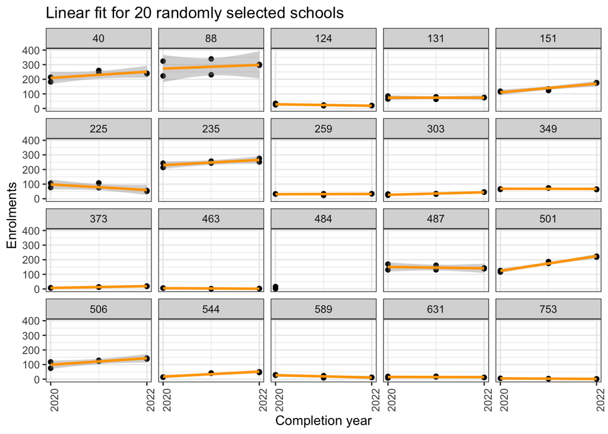

## Getting the data ready for modelling

### Linearise response variable using log transformation

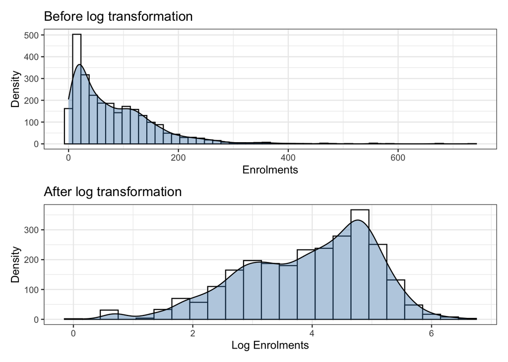

The enrolments were right skewed, which is likely to be attributed to the various school sizes (as seen in Figure 1). A log transformation was implemented to the response variable (*i.e.* `enrolments`) to allow the the multilevel model to better capture the enrolment patterns.

## Unconditional means model

```
## boundary (singular) fit: see ?isSingular
```

Table 1: AIC values for all candidate models for Essential Mathematics

|  | df | AIC |
| --- | --- | --- |
| Model0.2: Schools nested within districts | 4 | 3614.649 |
| Model0.0: Within schools | 3 | 3619.822 |
| Model0.1: Schools nested within postcodes | 4 | 3621.822 |

Referring back to step 3, three candidate models are fitted, with the AIC shown in Table 1. `Model0.2`, corresponding to having schools nested within districts is the best model, with optimised (lowest) AIC and will be used in the subsequent analysis.

### Intraclass correlation ($ICC$)

```
## Random effects:
```

```
##  Groups                       Name        Variance Std.Dev.
##  qcaa_school_id:qcaa_district (Intercept) 1.148377 1.07162
##  qcaa_district                (Intercept) 0.047705 0.21841
##  Residual                                 0.113995 0.33763
```

```
##
##  Fixed effects:
```

```
##             Estimate Std. Error  t value
## (Intercept) 3.841442 0.07919555 48.50577
```

```
##
##  Number of schools (level-two group) = 458
##  Number of district (level-three group) = 13
```

This model takes into account 458 schools nested in 13 districts. In a three-level multilevel model, two intraclass correlations can be obtained using the model summary output above:

The **level-two ICC** relates to the correlation between school $i$ from a certain district $k$ in time $t$ and in time $t^*$:

$$\text{Level-two ICC} = \frac{\tau^{2}_{00}}{\tau^{2}_{00} + \phi^{2}_{00} + \sigma^2} = \frac{1.1484}{(1.1484 + 0.0477 + 0.1140)} = 0.8766$$

This can be conceptualised as the correlation between enrolments of two random draws from the same school at two different years. In other words, 87.66% of the total variability is attributable to the differences between schools from the same district rather than changes over time within schools.

The **level-three ICC** refers to the correlation between different schools $i$ and $i^*$ from a specific school $j$.

$$\text{Level-three ICC} = \frac{\phi^2_{00}}{\tau^2_{00} + \phi^2_{00} + \sigma^2} = \frac{0.0477}{(1.1484 + 0.0477 + 0.1140)} = 0.0364$$

Similarly, it can be inferred that the correlation between enrolments of two randomly selected schools from different districts are 3.64%, where the total variability can be attributed to the difference between districts.

## Unconditional Growth model

```
##  Groups                       Name        Variance   Std.Dev. Corr
##  qcaa_district:qcaa_school_id (Intercept) 1.14444636 1.069788
##                               year20      0.04903558 0.221440 -0.088
##  qcaa_district                (Intercept) 0.04361994 0.208854
##                               year20      0.00082473 0.028718 0.230
##  Residual                                 0.07323625 0.270622
```

```
##               Estimate Std. Error   t value
## (Intercept) 3.78369587 0.07738087 48.897045
## year20      0.05820918 0.01485465  3.918583
```

```
##  Number of Level Two groups =  458
##  Number of Level Three groups =  13
```

The unconditional growth model adds the systematic changes over time, the model specification can be found in step 4. This allows for assessing within-school variability which can be attributed to the linear changes over time. Based on the model output:

- $\pi_{0ij}$ = 3.7837: Initial status for school $i$ in district $j$ (*i.e.* expected log enrolments when time = 0)
- $\pi_{1ij}$ = 0.0582: Growth rate for school $i$ in district $j$
- $\epsilon_{tij}$ = 0.0732: Variance in within-school residuals after accounting for linear growth overtime

Essential Mathematics was first introduced in 2020, and schools are expected to have 43.9785 ($e^{3.7837}$), on average. Furthermore, enrolments were expected to increase by 5.9937% ($e^{0.0582092} - 1) \times 100$) every year. The estimated within-school variance decrease by 35.7577% (0.1140 to 0.0732362), implying that 35.7577% of the within-school variability can be explained by the linear growth over time.

## Testing fixed effects

```
## # A tibble: 11 × 5
##    model      npar   AIC   BIC logLik
##    <chr>     <dbl> <dbl> <dbl>  <dbl>
##  1 model4.0     19 2947. 3058. -1454.
##  2 model4.6     15 2952. 3040. -1461.
##  3 model4.2     14 2952. 3034. -1462.
##  4 model4.8     14 2952. 3034. -1462.
##  5 model4.9     14 2952. 3034. -1462.
##  6 model4.10    14 2952. 3034. -1462.
##  7 model4.1     17 2955. 3055. -1461.
##  8 model4.7     16 2956. 3050. -1462.
##  9 model4.3     13 2981. 3058. -1478.
## 10 model4.4     14 2985. 3067. -1479.
## 11 model4.5     15 2985. 3073. -1478.
```

As detailed in step 6, level-two predictors (`sector` and `unit`) are added to the model. The largest possible model will be fitted, before removing each fixed effect one by one whilst recording the AIC for each model. `model4.0` corresponds to the largest model while `model4.10` is the smallest possible model. The model with the optimal (lowest) AIC is the largest possible model `model4.0`, and will be used in subsequent sections.

## Parametric bootstrap to test random effects

Table 2: Parametric Bootstrap to compare larger and smaller, nested model

| npar | AIC | BIC | logLik | deviance | Chisq | Df | Pr_boot(>Chisq) |
| --- | --- | --- | --- | --- | --- | --- | --- |
| 17 | 2944.454 | 3044.208 | -1455.227 | 2910.454 | NA | NA | NA |
| 19 | 2946.979 | 3058.468 | -1454.489 | 2908.979 | 1.47565 | 2 | 0.256 |

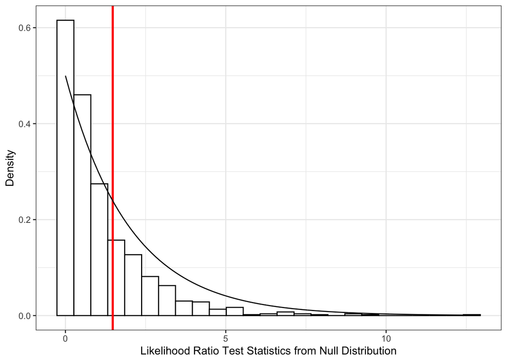

Figure 2: Histogram of likelihood ratio test statistic, with a red vertical line indicating the likelihood ratio test statistic for the actual model

The parametric bootstrap is used to approximate the likelihood ratio test statistic to produce a more accurate p-value by simulating data under the null hypothesis (detailed explanation can be found in step 7. Figure 2 displays the likelihood ratio test statistic from the null distribution, with the red line representing the likelihood ratio test statistic using the actual data.

## Confidence interval

Table 3: 95% confidence intervals for fixed and random effects in the final model

| var | 2.5 % | 97.5 % |
| --- | --- | --- |
| sd_(Intercept)\|qcaa_district:qcaa_school_id | 0.7489372 | 0.8615391 |
| cor_year20.(Intercept)\|qcaa_district:qcaa_school_id | -0.2253224 | -0.0015329 |
| sd_year20\|qcaa_district:qcaa_school_id | 0.2044296 | 0.2476368 |
| sd_(Intercept)\|qcaa_district | 0.1525776 | 0.4495489 |
| sigma | 0.2577367 | 0.2748534 |
| (Intercept) | 3.3929124 | 3.8944034 |
| year20 | 0.0209839 | 0.1432844 |
| sectorGovernment | 0.5992458 | 1.0092179 |
| sectorIndependent | -1.1713273 | -0.7385895 |
| unityear_12_enrolments | 0.0544900 | 0.1923526 |
| year20:sectorGovernment | -0.1098924 | 0.0381604 |
| year20:sectorIndependent | -0.0548805 | 0.1066265 |
| year20:unityear_12_enrolments | -0.1250023 | -0.0091553 |
| sectorGovernment:unityear_12_enrolments | -0.2852633 | -0.1176833 |
| sectorIndependent:unityear_12_enrolments | -0.0772452 | 0.1178977 |
| year20:sectorGovernment:unityear_12_enrolments | 0.0179056 | 0.1611691 |
| year20:sectorIndependent:unityear_12_enrolments | -0.0740500 | 0.0683533 |

The parametric bootstrap is utilised to construct confidence intervals (as detailed in step 8). If the confidence intervals for the random effects does not include 0, it provides statistical evidence that the p-value is less than 0.5. In other words, it suggests that the random effects and the correlation between the random effects are significant at the 5% level. The 95% confidence interval is shown above (Table 3), and the random effects all exclude 0, further reiterating that they are statistically significant at the 5% level.

## Interpreting final model

### Fixed effects

- Level one (measurement variable)
  $$Y_{tij} = \pi_{0ij} + \pi_{1ij}year20_{tij} + \epsilon_{tij}$$
- Level two (schools within districts)
  $$\pi_{0ij} = \beta_{00j} + \beta_{01j}sector_{ij} + \beta_{02j}unit_{ij} + \beta_{03j}sector_{ij}unit_{ij} + u_{0ij} \\
  \pi_{1ij} = \beta_{10j} + \beta_{11j}sector_{ij} + \beta_{12j}unit_{ij} + \beta_{03j}sector_{ij}unit_{ij} + u_{1ij}$$
- Level three (districts)
  $$\beta_{00j} = \gamma_{000} + r_{00j} \\
  \beta_{01j} = \gamma_{010} + r_{01j} \\
  \beta_{02j} = \gamma_{020} + r_{02j} \\
  \beta_{03j} = \gamma_{030} + r_{03j} \\
  \beta_{10j} = \gamma_{100} \\
  \beta_{11j} = \gamma_{110} \\
  \beta_{12j} = \gamma_{120} \\
  \beta_{13j} = \gamma_{130}$$

Therefore, the composite model can be written as

$$
$$\begin{aligned}
Y_{tij} =\ &\pi_{0ij} + \pi_{1ij}year92_{tij} + \epsilon_{tij} \\
=\ & (\beta_{00j} + \beta_{01j}sector_{ij} + \beta_{02j}unit_{ij} + \beta_{03j}sector_{ij}unit_{ij} + u_{0ij}) + \\
& (\beta_{10j} + \beta_{11j}sector_{ij} + \beta_{12j}unit_{ij} + \beta_{13j}sector_{ij}unit_{ij} + u_{1ij})year20_{tij} +
\epsilon_{tij} \\
=\ & \left[\gamma_{000} + r_{00j} + (\gamma_{010} + r_{01j})sector_{ij} + (\gamma_{020} + r_{02j})unit_{ij} +
(\gamma_{030} + r_{03j})sector_{ij}unit_{ij} + u_{0ij} \right] + \\
& \left[\gamma_{100} + \gamma_{110}sector_{ij} + \gamma_{120}unit_{ij} + \gamma_{130}sector_{ij}unit_{ij} + u_{1ij}
\right]year20_{tij} + \epsilon_{tij} \\
=\ & \left[\gamma_{000} + \gamma_{010}sector_{ij} + \gamma_{020}unit_{ij} + \gamma_{030}sector_{ij}unit_{ij} +
\gamma_{100}year20_{tij} + \gamma_{110}sector_{ij}year_{tij} + \gamma_{120}unit_{ij}year_{tij} +
\gamma_{130}sector_{ij}unit_{ij}year_{tij} \right] \\
& \left[r_{00j} + r_{01j}sector_{ij} + r_{02j}unit_{ij} + r_{03j}sector_{ij}unit_{ij} + u_{0ij} + u_{1ij}year20_{tij} + \epsilon_{tij} \right]
\end{aligned}$$

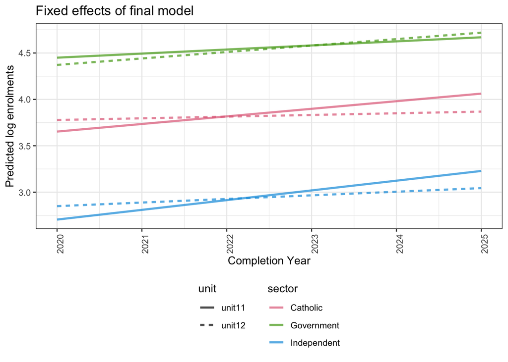

Figure 3: Fixed effects of the final model for Essential Mathematics

### Random effects

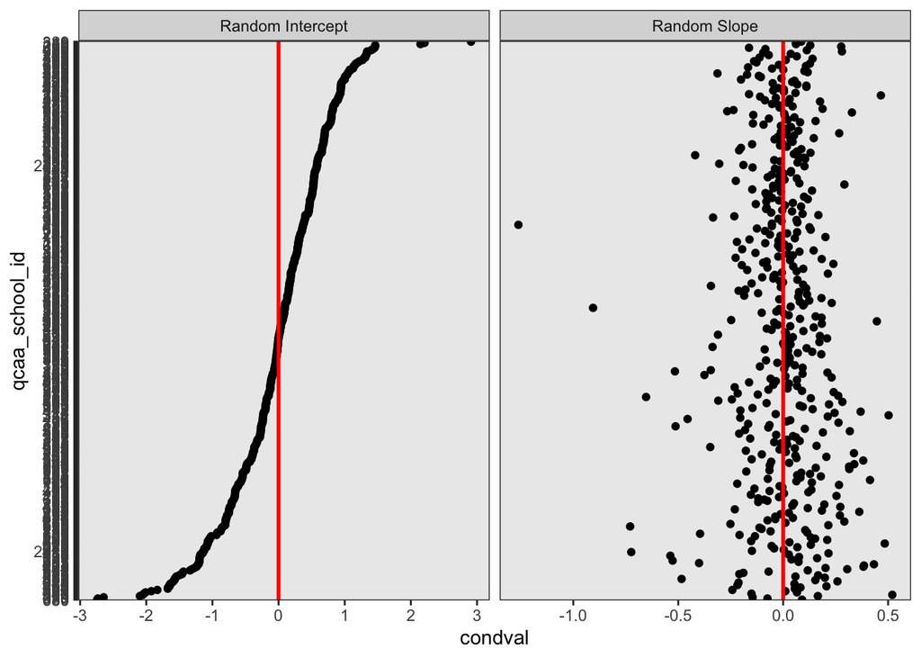

Figure 4: Random effects for schools

As shown in the model output and in Figure 4, there was little correlation (-0.12) between the random intercept and slope. Schools with appear to decrease or increase in enrolments at different rates; This may be attributed to the fact that the data only consists of observations for three years and there is not enough data to evaluate the enrolment patterns in schools.

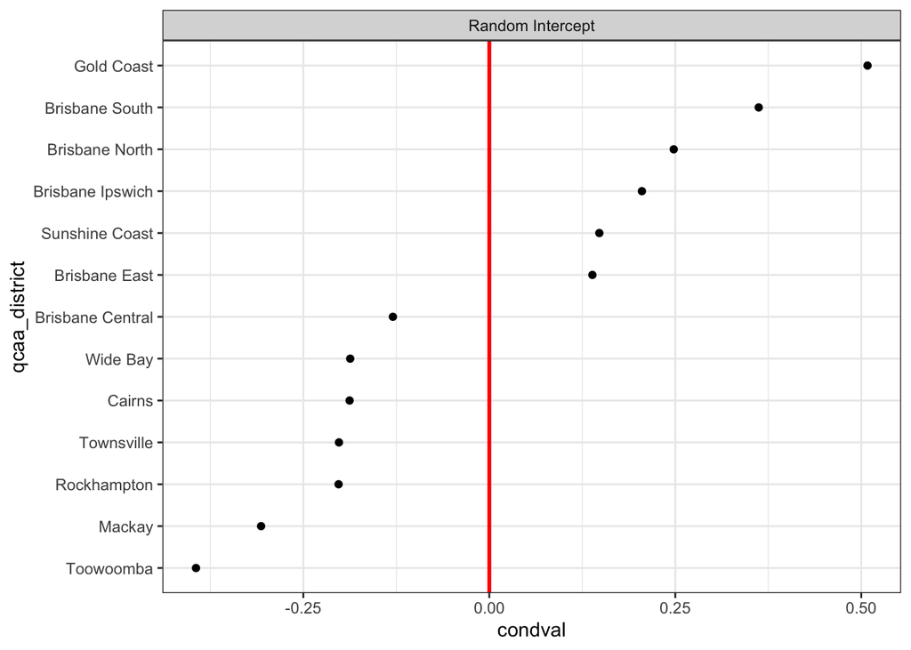

Figure 5: Random intercept for districts

### Predictions

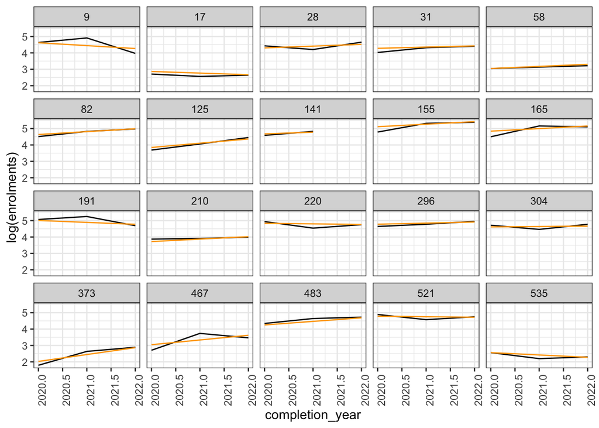

Figure 6: Model predictions for 20 randomly selected schools

Figure 6 above shows the predictions for 20 randomly selected schools.